# BMIN503/EPID600 Final Project: Maternal Health in Philadelphia

Jessica Meeker

### Overview

Maternal mortality and morbidity rates have seen a decline globally; however, in the United States these numbers continue to rise, in particular among women of color. I will use Electronic Medical Record (EMR) data from a cohort of women in the University of Pennsylvania Health System (UPHS). The goal of this project is to perform exploratory statistical methods to describe the exposure and outcome variables in the data set and machine learning methods (Lasso) to create a model of neighborhood level stress in Philadelphia that predicts maternal mortality and morbidity.

I spoke with Drs. Trevor Penning, Ray Bai & Mary Regina Boland about my project. With Dr. Penning I discussed the project from a more broad lens of environmental exposures, both natural and social. Dr. Bai was able to provide much needed insight into the methodology of logistic regression with a lasso penalty on the predictors. Dr. Boland and I discussed overall project context and some of the considerations necessary for which machine learning method to choose.

[Github Repository](https://github.com/jemeeker10/BMIN503_Final_Project)

### Introduction

Maternal morbidity and mortality persist as key indicators of women’s health both globally and in the US. Pregnancy related deaths that occur during pregnancy or within a year following pregnancy, have strikingly doubled from 7.2 deaths per 100,000 live births in 1987 to 18.0 deaths in 2014. While mortality is steadily increasing nationally, severe maternal morbidity (SMM) is actually far more common in the US than maternal mortality by nearly 100 times. SMM describes unexpected, poor outcomes of labor or delivery that may result in short or long term consequences that can be significant for the mother, child and their family. However, not all women are at equal risk for SMM or maternal mortality and severe health disparities persist. Notably, African American women are upwards of four times as likely to die of complications from pregnancy as compared to white women. To date, no genetic variant has been found to explain this discrepancy, begging the question of what else is transpiring to propagate such a stark health disparity. In this project I am interested in understanding the role the social, built, and natural environments play on these maternal health disparities.

This problem is very multidisciplinary in nature as it’s success depends upon collaboration of those from a variety of fields including maternal health clinicians, epidemiologists, statisticians, informaticians, environmental toxicologists, and health disparities researchers. I was privileged to be able to meet with three people who were trained in or who have significant experience in all of these roles. This problem is complex as it is a environmental, maternal health, and social disparities problem. In meeting with the three people I consulted regarding this project, I was provided with conceptual and methodological advice that will aid in the success of this project.

### Methods

The primary data sets used for this project include: 1) publically available data from the American Community Survey (ACS) from the Census Bureau 2) non-publically available data from the UPHS electronic medical record (EMR) system and 3) shape files from the Census Bureau. Multiple ACS files were used in the lasso prediction model, so as to let the algorithm decide which covariates were of most importance. Please note the socio-demographic variables that were used outlined in the methods code. The maternal health data which was derived from the UPHS EMR, is from 2010-2017 and includes pregnant women who were seen in the Penn System throughout their pregnancy.

First, all necessary packages are loaded.

```r
#All package libraries
library(dplyr)
library(tidycensus)
library(tidyverse)
library(sf)
library(ggplot2)
library(tidycensus)
library(tigris)
library(sp)
library("pROC")
```

Next, we load in all of our predictor variables from the ACS and clean the data for analysis.

```r
#ACS DATA
#vars <- load_variables(dataset = "acs5",  # specify ACS 5-year estimates
                       #year = 2016)  # specify end year (i.e. this queries ACS 5-year estimates for 2011-2016)

#Let's pull out the variables we want
acs.data <- get_acs(geography = "tract", year=2016,
                  state = "PA", county = "Philadelphia", geometry = TRUE,
                  variables = c(female_total = "B01001_026",
                                median.gross.rent = "B25064_001",
                                median.household.income = "B19013_001",
                                rent.burden = "B25071_001",
                                fem_nhwhite = "B01001H_017",
                                fem_afam = "B01001B_017",
                                fem_hispanic = "B01001I_017",
                                fem_amind_alask = "B01001C_017",
                                fem_asian = "B01001D_017",
                                fem_nh.pi = "B01001E_017",
                                fem_multiple = "B01001G_017",
                                fem_other = "B01001F_017",
                                med.house.income = "B19013_001",
                                med.house.value = "B25077_001",
                                poverty.estimate = "B17010_002",
                                poverty.total = "B17010_001",
                                fem.educ.total = "B15002_019", #these are for women over 25
                                fem.educ.none = "B15002_020",
                                fem.educ.ninth = "B15002_024",
                                fem.educ.hsgrad = "B15002_028",
                                fem.educ.coll = "B15002_032",
                                fem.educ.doc = "B15002_035",
                                fem.educ.masters = "B15002_033"))
#Let's put the data in a format we can work with.
acs.data.2 <- acs.data %>%
  group_by(GEOID) %>%  # return only one row per GEOID
  mutate(pov_fam = estimate[variable == "poverty.estimate"],
         tot_fam = estimate[variable == "poverty.total"],  # extract and rename total number of families
         percent_poverty = (pov_fam/tot_fam)*100) %>%
  mutate(female_total = estimate[variable == "female_total"],
         fem.educ.total = estimate[variable == "fem.educ.total"],
         fem.educ.none = estimate[variable == "fem.educ.none"],
         fem.educ.ninth = estimate[variable == "fem.educ.ninth"],
         fem.educ.hsgrad = estimate[variable == "fem.educ.hsgrad"],
         fem.educ.coll = estimate[variable == "fem.educ.coll"],
         fem.educ.doc = estimate[variable == "fem.educ.doc"],
         fem.educ.masters = estimate[variable == "fem.educ.masters"],
         percent_hsgrad = (fem.educ.hsgrad/fem.educ.total)*100) %>%
  mutate(median.gross.rent = estimate[variable == "median.gross.rent"],
         median.household.income = estimate[variable == "median.household.income"],
         rent.burden = estimate[variable == "rent.burden"]) %>%
  mutate(fem_nhwhite = estimate[variable == "fem_nhwhite"],
         fem_afam = estimate[variable == "fem_afam"],
         fem_hispanic = estimate[variable == "fem_hispanic"],
         fem_amind_alask = estimate[variable == "fem_amind_alask"],
         fem_asian = estimate[variable == "fem_asian"],
         fem_nh.pi = estimate[variable == "fem_nh.pi"],
         fem_multiple = estimate[variable == "fem_multiple"],
         fem_other = estimate[variable == "fem_other"],
         percent_white = ((fem_nhwhite/(fem_nhwhite + fem_afam + fem_hispanic + fem_amind_alask + fem_asian + fem_nh.pi + fem_multiple + fem_other))*100)) %>%
  mutate(percent_minority = (100-percent_white))%>%
  select(GEOID, NAME, pov_fam, tot_fam, percent_poverty, female_total, fem.educ.total, fem.educ.none, fem.educ.ninth, fem.educ.hsgrad, fem.educ.coll, fem.educ.doc, fem.educ.masters, percent_hsgrad, median.gross.rent, median.household.income, rent.burden, fem_nhwhite, fem_afam, fem_hispanic, fem_amind_alask, fem_asian, fem_nh.pi, fem_multiple, fem_other, percent_white, percent_minority)
```

Next we needed to pull in the patient level maternal health data from Penn. Since this is PHI data, I am ommitting the initial code used to import the data from SQL.

First I imported the data, then I merged a dataset of women with encounters at UPHS with a dataset that had outcome data for their deliveries. These variables include information about stillbirth, preterm birth, preeclampsia, hypertnesion and C-section. Then I cleaned the data.

```r
#these libraries were used in the code I used to tunnel in to the data, which has been ommitted here.
##library(RMySQL)
##library("DBI")
##library(stringr)

#Merging the data sets together
dim(encounter_at_deliv)
```

```
## [1] 63334    53
```

```r
dim(mat_outcomes)
```

```
## [1] 63334    37
```

```r
encounter_at_deliv_woutcomes = merge(encounter_at_deliv, mat_outcomes, by="PREG_ID")
dim(encounter_at_deliv_woutcomes)
```

```
## [1] 63334    89
```

```r
#get rid of NAs
encounter_at_deliv_woutcomes_NAlatlonrem=encounter_at_deliv_woutcomes[-which(encounter_at_deliv_woutcomes$LATITUDE=="NA"), ]
encounter_at_deliv_woutcomes_NAlatlonrem=encounter_at_deliv_woutcomes_NAlatlonrem[-which(encounter_at_deliv_woutcomes_NAlatlonrem$LONGITUDE=="NA"), ]
dim(encounter_at_deliv_woutcomes_NAlatlonrem)
```

```
## [1] 31448    89
```

```r
#get rid of blanks
encounter_at_deliv_woutcomes_NAlatlonrem_blanks=encounter_at_deliv_woutcomes_NAlatlonrem[-which(encounter_at_deliv_woutcomes_NAlatlonrem$LATITUDE==""), ]
encounter_at_deliv_woutcomes_NAlatlonrem_blanks=encounter_at_deliv_woutcomes_NAlatlonrem[-which(encounter_at_deliv_woutcomes_NAlatlonrem$LONGITUDE==""), ]
dim(encounter_at_deliv_woutcomes_NAlatlonrem_blanks)
```

```
## [1] 29275    89
```

```r
outcome.data <- data.frame(encounter_at_deliv_woutcomes_NAlatlonrem_blanks)
class(outcome.data)
```

```
## [1] "data.frame"
```

```r
#Choose only the variables we want
outcome.data_clean <- select(outcome.data,PREG_ID,LATITUDE,LONGITUDE,MRN_HUP,YEAR,NH_AFAM,NH_WHITE,HISPANIC,WEIGHT_LBS,ENC_AGE_DEC.x,STILLBIRTH,PRETERM,CSECTION, HYPERTENSION, PREECLAMPSIA)
dim(outcome.data_clean)
```

```
## [1] 29275    15
```

Next, we needed to add GEOIDs to each patient to merge it with ACS data.

```r
#Take the patient data and append GEOIDs to each patient's address so that we can link it with ACS data
# (!) fill this:
data_path <- "C:/Users/Jessi/Documents/Blanca Class/finally project/"
load(paste0(data_path,"phillytracts"))

# (!) let's call the dataset data.pre
data.pre <- outcome.data_clean
data.pre$LATITUDE[which(data.pre$LATITUDE=="")]=NA
data.pre$LONGITUDE[which(data.pre$LONGITUDE=="")]=NA

# GPS location:
temp.pointX <- data.pre$LATITUDE
temp.pointY <- data.pre$LONGITUDE

## actually they have the same NAs, but just in case
rem.ind.points <- is.na(temp.pointX) | is.na(temp.pointY)
## want to make this exact same as old file. Remove extraneous points, keep order:
# (!) add other covariates we care about
data.new <- data.pre[!rem.ind.points,]
data.new$LATITUDE=as.numeric(as.character(data.new$LATITUDE))
data.new$LONGITUDE=as.numeric(as.character(data.new$LONGITUDE))
pts <- SpatialPoints(data.new[ ,c('LONGITUDE', 'LATITUDE')])
databytracts <- sp::over(tracts, pts, returnList = T)

data.new$tract <- NA
data.new$tractID <- NA

datavector <- unlist(databytracts)
datatractlength <- lapply(databytracts, length)

levels_region <- levels(tracts@data$GEOID10)[tracts@data$GEOID10]

dataind.temp <- c(0, cumsum(datatractlength))
for(i in 1:length(databytracts)){
  temp.index <- (dataind.temp[i] + 1): (dataind.temp[i + 1])
  data.new$tract[datavector[temp.index]] = i
  data.new$tractID[datavector[temp.index]] = levels_region[i]
  if(i %% 100 == 0) cat(i, " ")
}
```

```
## 100  200  300
```

```r
sum(is.na(data.new$tractID))
```

```
## [1] 7850
```

```r
dim(data.new)
```

```
## [1] 29275    17
```

```r
data.new.philly=data.new[-which(is.na(data.new$tractID)), ]
#View(data.new.philly)
dim(data.new.philly)
```

```
## [1] 21425    17
```

```r
table(data.new.philly$tract)
```

```
##
##   1   2   3   4   5   6   7   8   9  10  11  12  13  14  15  16  17  18  19  20  21  22  23  24  25  26  27  28  29  30  31  32  33  34  35  36  37  38  39  40  41  42  43  44  45  46  47  48  49  50  51  52  53  54  55  56  57  58  59  60  61  62  63  64  65  66  67  68  69  70  71  72  73  74  …
##   9   1  17  15   7  11 132 135  28  45  33   1   8  22   2 143   1   5  32  11  10  50  63  16  27  38  29  31  34  43  24  49  13  20  25  56  38  73  50  54  39   5   4   6   6  31  79   3   1  37  29  91  97  40  31   9  16  20  12  24   6   5  12 210 249 254 230 145 238 136 171 133 329 185 1…
## 101 102 103 104 105 106 107 108 109 110 111 112 113 114 115 116 117 118 119 120 121 122 123 124 125 126 127 128 129 130 131 132 133 134 135 136 137 138 139 140 141 142 143 144 145 146 147 148 149 150 151 152 153 154 155 156 157 158 159 160 161 162 163 164 165 166 167 168 169 170 171 172 173 174 1…
##  81  74  14  29  92  74  80  81  44  40  15  64  36  43  29  19 224 168  88  76 101 116 115  77  72  66  89 182 145 134 150   1   9 128  12 240 122 241 209  75 133  97  71  76  86  36  88  94  43  84  87 146  58 104  50 165 237 122  26  40  70  42  25  63 155 101  58 102   2  33  50  25  23  41  …
## 201 202 203 204 205 206 207 208 209 210 211 212 213 214 215 216 217 218 219 220 221 222 223 224 225 226 227 228 229 230 231 232 233 234 235 236 237 238 239 240 241 242 243 244 245 246 247 248 249 250 251 252 253 254 255 256 257 258 259 260 261 262 263 264 265 266 267 268 269 270 271 272 273 274 2…
##  48  51  65   6   9   4  20  13  11   8  11   3   1  10   2 192 162 144 352  56 142 157  72 131  15  67  77   3  79  74   9  16  20  13  19  33 106 126  29  56  47  25  78  90  86  65  40 100  57  18   7   8   4  17   8  29  31  43   9  36  16  13  21  18  16  23   6  35  31  36  43  48  20  57 1…
## 301 302 303 304 305 306 307 308 309 310 311 312 313 314 315 316 317 318 319 320 321 322 323 324 325 326 327 328 329 330 331 332 333 334 335 336 337 338 339 340 341 342 343 344 345 346 347 348 349 350 351 352 353 354 355 356 357 358 359 360 361 362 363 364 365 366 367 368 369 370 371 372 373 374 3…
## 103 103 208   1 152   1  11  11  12  29  26  63  40  42  17  77 188  12  20  48 169  41  17   1 102   2   3  28  70 188   1  15  49  56  35   8  74  25  10   8  23  60  26   5  14   7  12  34  47  35  36  33  32  50  32  50  47  56  63  40  47  53  49   1  22  69  10   1  10   7   9   4   2  16  …
```

```r
num.tracts = length(unique(data.new.philly$tract))
unique_tracts = unique(data.new.philly$tract)

num_deliv=rep(NA,num.tracts)
num_preterm=rep(NA,num.tracts)
num_stillbirth=rep(NA,num.tracts)
num_Csection=rep(NA,num.tracts)
for(i in 1:length(unique(data.new.philly$tract))){
  data_it = subset(data.new.philly, data.new.philly$tract==unique_tracts[i])
  num_deliv[i] = length(unique(data_it$PREG_ID))
  num_preterm[i] = length(unique(data_it$PREG_ID[which(data_it$PRETERM=="1")]))
  num_stillbirth[i] = length(unique(data_it$PREG_ID[which(data_it$STILLBIRTH=="1")]))
  num_Csection[i] = length(unique(data_it$PREG_ID[which(data_it$CSECTION=="1")]))
}
counts_outcomes_philly_geo = data.frame(tract=unique_tracts,
                                        num_deliv=num_deliv,
                                        num_Csection=num_Csection,
                                        num_preterm=num_preterm,
                                        num_stillbirth=num_stillbirth)


tract_df = data.frame(tract=data.new.philly$tract,
                      tractID=data.new.philly$tractID)

tract_df=tract_df[!(duplicated(tract_df)), ]

counts_outcomes_philly_geo=merge(counts_outcomes_philly_geo,tract_df, by="tract" )

dim(counts_outcomes_philly_geo)
```

```
## [1] 384   6
```

```r
dim(data.new.philly)
```

```
## [1] 21425    17
```

Now, we need to merge data.new.philly (the geocoded maternal health outcome data) with acs.data.2.

```r
class(data.new.philly$tractID)
```

```
## [1] "character"
```

```r
class(acs.data.2$GEOID)
```

```
## [1] "character"
```

```r
#first need to make GEOID column in data.new.philly to merge on
data.new.philly$GEOID=data.new.philly$tractID
class(data.new.philly$GEOID)
```

```
## [1] "character"
```

```r
outcome_acs = merge(acs.data.2, data.new.philly, by="GEOID")
dim(outcome_acs)
```

```
## [1] 471350     45
```

```r
outcome_acs_clean = outcome_acs[!(duplicated(outcome_acs)), ]
dim(outcome_acs_clean)
```

```
## [1] 21425    45
```

```r
class(outcome_acs)
```

```
## [1] "sf"         "data.frame"
```

```r
colnames(outcome_acs)
```

```
##  [1] "GEOID"                   "NAME"                    "pov_fam"                 "tot_fam"                 "percent_poverty"         "female_total"            "fem.educ.total"          "fem.educ.none"           "fem.educ.ninth"          "fem.educ.hsgrad"         "fem.educ.coll"           "fem.e…
## [16] "median.household.income" "rent.burden"             "fem_nhwhite"             "fem_afam"                "fem_hispanic"            "fem_amind_alask"         "fem_asian"               "fem_nh.pi"               "fem_multiple"            "fem_other"               "percent_white"           "perce…
## [31] "MRN_HUP"                 "YEAR"                    "NH_AFAM"                 "NH_WHITE"                "HISPANIC"                "WEIGHT_LBS"              "ENC_AGE_DEC.x"           "STILLBIRTH"              "PRETERM"                 "CSECTION"                "HYPERTENSION"            "PREEC…
```

### Results

Bar Plots were generated to look at overall outcome counts

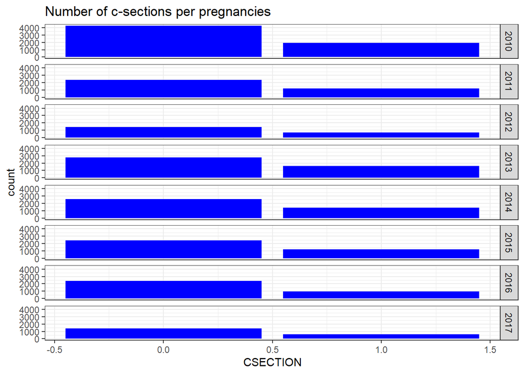

```r
#bar plot for c-section
##by year
ggplot(data = outcome.data_clean, aes(x = CSECTION, group = YEAR,)) +
  geom_bar(stat = "count", fill = "blue") +
  ggtitle ("Number of c-sections per pregnancies") +
  theme_bw() +
  facet_grid(YEAR ~ .)
```

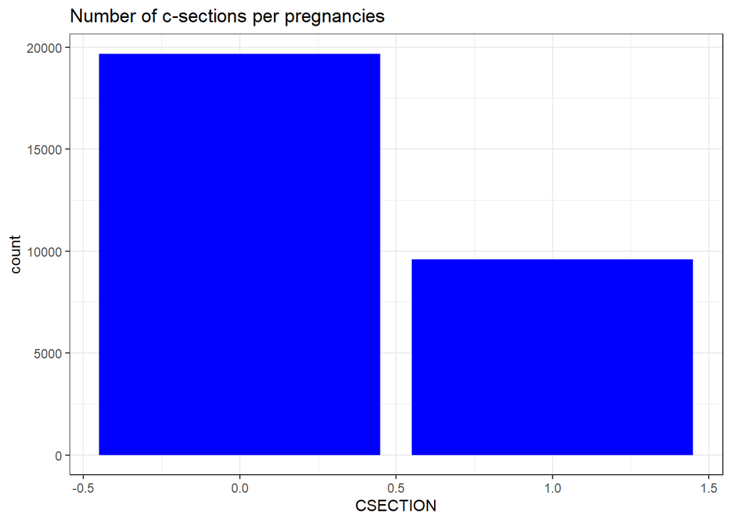

```r
##overall
ggplot(data = outcome.data_clean, aes(x = CSECTION, group = YEAR,)) +
  geom_bar(stat = "count", fill = "blue") +
  ggtitle ("Number of c-sections per pregnancies") +
  theme_bw()
```

```r
#table for c-section
table(outcome.data_clean$CSECTION)
```

```
##
##     0     1
## 19683  9592
```

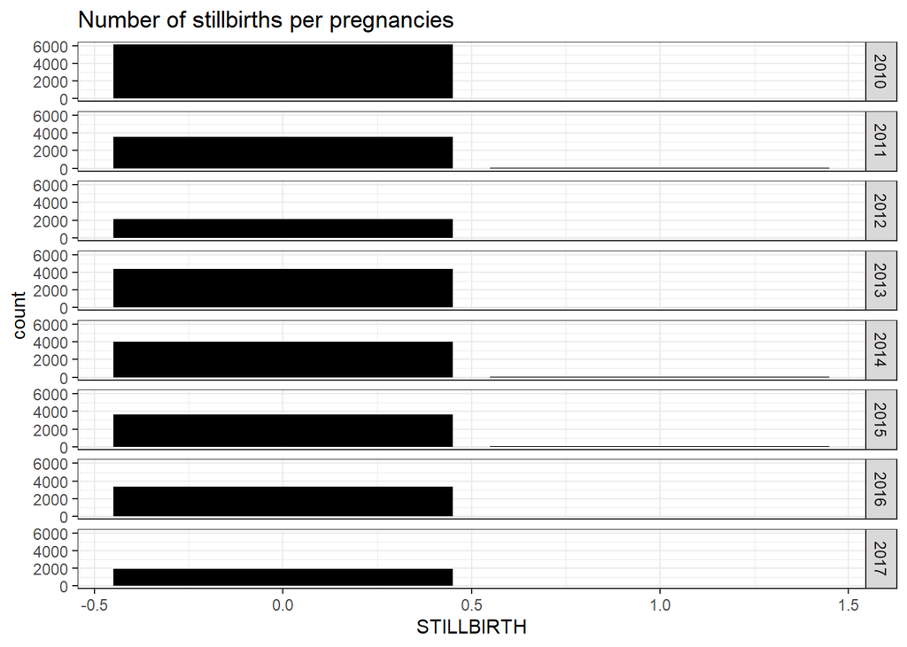

```r
#bar plot for stillbirth
##by year
ggplot(data = outcome.data_clean, aes(x = STILLBIRTH, group = YEAR)) +
  geom_bar(stat = "count", fill = "black") +
  ggtitle ("Number of stillbirths per pregnancies") +
  theme_bw() +
  facet_grid(YEAR ~ .)
```

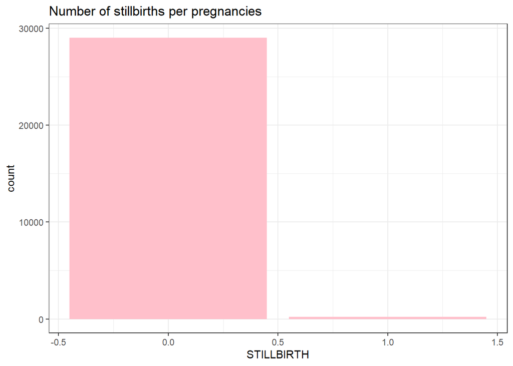

```r
#overall
ggplot(data = outcome.data_clean, aes(x = STILLBIRTH, group = YEAR)) +
  geom_bar(stat = "count", fill = "pink") +
  ggtitle ("Number of stillbirths per pregnancies") +
  theme_bw()
```

```r
##table for stillbirth
table(outcome.data_clean$STILLBIRTH)
```

```
##
##     0     1
## 29042   233
```

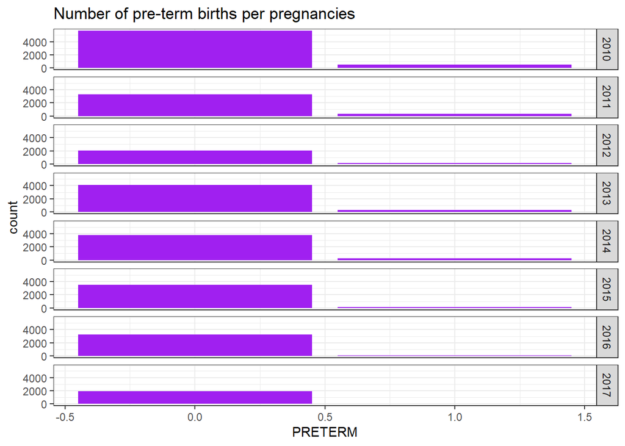

```r
#bar plot for pre-term birth
##by year
ggplot(data = outcome.data_clean, aes(x = PRETERM, group = YEAR)) +
  geom_bar(stat = "count", fill = "purple") +
  ggtitle ("Number of pre-term births per pregnancies") +
  theme_bw() +
  facet_grid(YEAR ~ .)
```

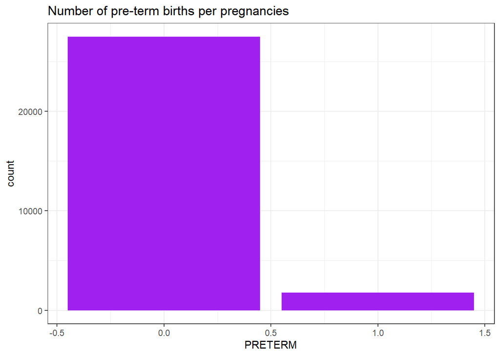

```r
##overall
ggplot(data = outcome.data_clean, aes(x = PRETERM, group = YEAR)) +
  geom_bar(stat = "count", fill = "purple") +
  ggtitle ("Number of pre-term births per pregnancies") +
  theme_bw()
```

```r
##table for preterm birth
table(outcome.data_clean$PRETERM)
```

```
##
##     0     1
## 27515  1760
```

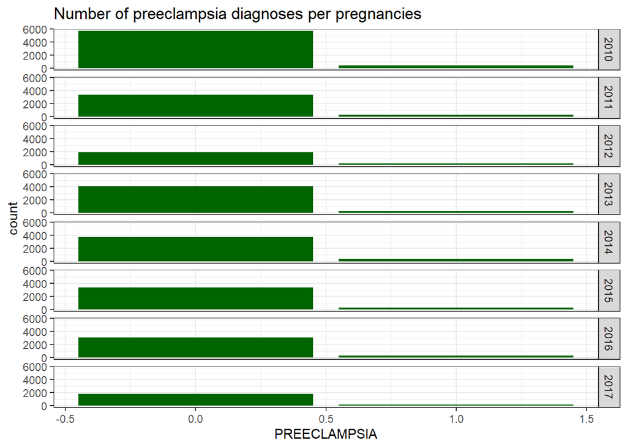

```r
#bar plot for pre-eeclampsia
##by year
ggplot(data = outcome.data_clean, aes(x = PREECLAMPSIA, group = YEAR)) +
  geom_bar(stat = "count", fill = "dark green") +
  ggtitle ("Number of preeclampsia diagnoses per pregnancies") +
  theme_bw() +
  facet_grid(YEAR ~.)
```

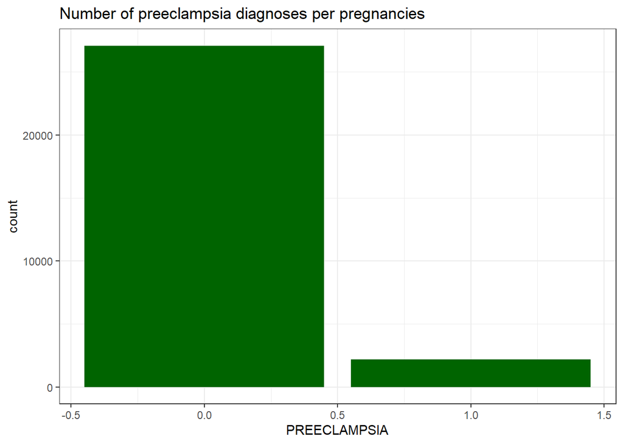

```r
##overall
ggplot(data = outcome.data_clean, aes(x = PREECLAMPSIA, group = YEAR)) +
  geom_bar(stat = "count", fill = "dark green") +
  ggtitle ("Number of preeclampsia diagnoses per pregnancies") +
  theme_bw()
```

```r
#table for preeclampsia
table(outcome.data_clean$PREECLAMPSIA)
```

```
##
##     0     1
## 27080  2195
```

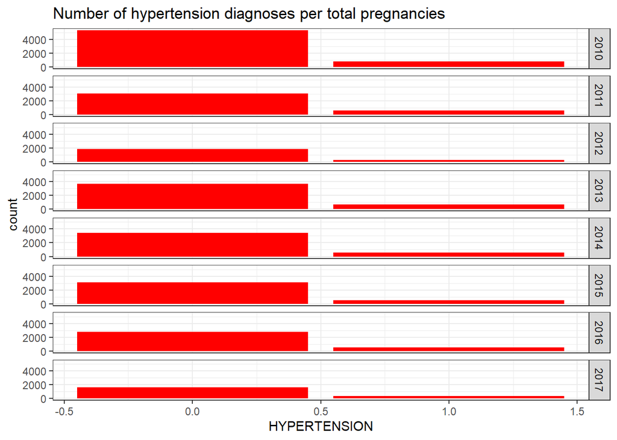

```r
#bar plot for hypertension
##by year
ggplot(data = outcome.data_clean, aes(x = HYPERTENSION, group = YEAR)) +
  geom_bar(stat = "count", fill = "red") +
  ggtitle ("Number of hypertension diagnoses per total pregnancies") +
  theme_bw() +
  facet_grid(YEAR ~.)
```

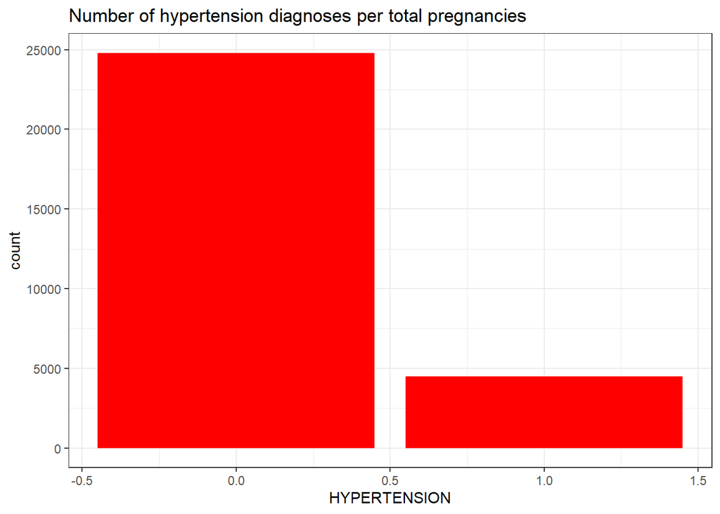

```r
##overall
ggplot(data = outcome.data_clean, aes(x = HYPERTENSION, group = YEAR)) +
  geom_bar(stat = "count", fill = "red") +
  ggtitle ("Number of hypertension diagnoses per total pregnancies") +
  theme_bw()
```

```r
#table for hypertension
table(outcome.data_clean$HYPERTENSION)
```

```
##
##     0     1
## 24802  4473
```

```r
#make race category for graph
outcome.data_clean <- outcome.data_clean %>%
  mutate(RACE = ifelse(NH_AFAM == 1, "black",
                  ifelse(NH_WHITE == 1, "white",
                  ifelse(HISPANIC ==1, "hispanic", "no answer"))))

table(outcome.data_clean$RACE)
```

```
##
##     black  hispanic no answer     white
##     12775      2698      2967     10835
```

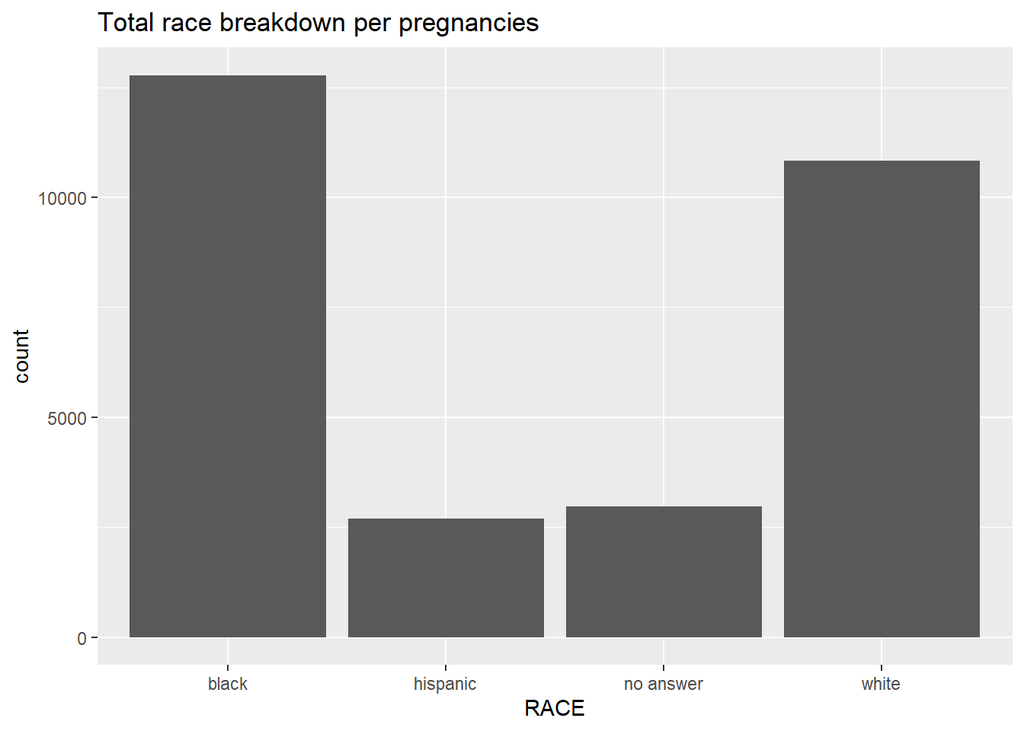

```r
#bar plot for race
ggplot (data = outcome.data_clean, aes (x = RACE)) +
  geom_bar(stat = "count") +
  ggtitle("Total race breakdown per pregnancies")
```

Let’s look at a plot that shows all of the outcome variables together as percents.

```r
#Looking at A bar plot of all the variables together
#9592/19682 = 49%
outcome.data_clean%>%
  filter(CSECTION==1)%>%
  count()
```

```
## # A tibble: 1 x 1
##       n
##   <int>
## 1  9592
```

```r
outcome.data_clean%>%
  filter(CSECTION==0)%>%
  count()
```

```
## # A tibble: 1 x 1
##       n
##   <int>
## 1 19683
```

```r
#1760/27515 = 6.4%
outcome.data_clean%>%
  filter(PRETERM==1)%>%
  count()
```

```
## # A tibble: 1 x 1
##       n
##   <int>
## 1  1760
```

```r
outcome.data_clean%>%
  filter(PRETERM==0)%>%
  count()
```

```
## # A tibble: 1 x 1
##       n
##   <int>
## 1 27515
```

```r
#18%
outcome.data_clean%>%
  filter(HYPERTENSION==1)%>%
  count()
```

```
## # A tibble: 1 x 1
##       n
##   <int>
## 1  4473
```

```r
outcome.data_clean%>%
  filter(HYPERTENSION==0)%>%
  count()
```

```
## # A tibble: 1 x 1
##       n
##   <int>
## 1 24802
```

```r
#8.1%
outcome.data_clean%>%
  filter(PREECLAMPSIA==1)%>%
  count()
```

```
## # A tibble: 1 x 1
##       n
##   <int>
## 1  2195
```

```r
outcome.data_clean%>%
  filter(PREECLAMPSIA==0)%>%
  count()
```

```
## # A tibble: 1 x 1
##       n
##   <int>
## 1 27080
```

```r
#1%
outcome.data_clean%>%
  filter(STILLBIRTH==1)%>%
  count()
```

```
## # A tibble: 1 x 1
##       n
##   <int>
## 1   233
```

```r
outcome.data_clean%>%
  filter(STILLBIRTH==0)%>%
  count()
```

```
## # A tibble: 1 x 1
##       n
##   <int>
## 1 29042
```

```r
9592/19682
```

```
## [1] 0.4873488
```

[figure not shown]

```r
percents <- data.frame("Variable" = c("CSECTION", "PRETERM", "HYPERTENSION", "PREECLAMPSIA", "STILLBIRTH"), "Percent" = c(49,7,18,8,1))

ggplot (data = percents, aes (x = Variable, y=Percent)) +
  geom_bar(stat="identity") +
  ggtitle("Percents of morbidities per total number of pregnancies")
```

Now let’s take a look at the pattern of how certain outcomes map together.

```r
# to look at the women who have different combinations of outcomes
outcome.data_clean %>%
  group_by(PRETERM, CSECTION, PREECLAMPSIA, HYPERTENSION, STILLBIRTH) %>%
  summarise(n = n())
```

```
## # A tibble: 29 x 6
## # Groups:   PRETERM, CSECTION, PREECLAMPSIA, HYPERTENSION [16]
##    PRETERM CSECTION PREECLAMPSIA HYPERTENSION STILLBIRTH     n
##      <dbl>    <dbl>        <dbl>        <dbl>      <dbl> <int>
##  1       0        0            0            0          0 15342
##  2       0        0            0            0          1   130
##  3       0        0            0            1          0  2142
##  4       0        0            0            1          1    21
##  5       0        0            1            0          0   605
##  6       0        0            1            0          1    13
##  7       0        0            1            1          0   340
##  8       0        0            1            1          1    10
##  9       0        1            0            0          0  6619
## 10       0        1            0            0          1    15
## # ... with 19 more rows
```

Download shape file for Philadelphia for mapping purposes and join it to the acs data.

```r
#import city shapefile as an sf object

#Pull in Phila cencus tracts shape file

philly.tracts <- readRDS(gzcon(url("https://raw.githubusercontent.com/HimesGroup/BMIN503/master/DataFiles/philadelphia_tracts_2010.rds")))

# Note philly.tracts is an sf ("simple feature") object of type "MULTIPOLYGON"
head(philly.tracts)
```

```
## Simple feature collection with 6 features and 14 fields
## geometry type:  MULTIPOLYGON
## dimension:      XY
## bbox:           xmin: -75.24747 ymin: 39.96047 xmax: -75.15853 ymax: 39.98
## epsg (SRID):    4326
## proj4string:    +proj=longlat +datum=WGS84 +no_defs
##   OBJECTID STATEFP10 COUNTYFP10 TRACTCE10     GEOID10 NAME10       NAMELSAD10 MTFCC10 FUNCSTAT10 ALAND10 AWATER10  INTPTLAT10   INTPTLON10 LOGRECNO                       geometry
## 0        1        42        101    009400 42101009400     94  Census Tract 94   G5020          S  366717        0 +39.9632709 -075.2322437    10429 MULTIPOLYGON (((-75.22927 3...
## 1        2        42        101    009500 42101009500     95  Census Tract 95   G5020          S  319070        0 +39.9658709 -075.2379140    10430 MULTIPOLYGON (((-75.23536 3...
## 2        3        42        101    009600 42101009600     96  Census Tract 96   G5020          S  405273        0 +39.9655396 -075.2435075    10431 MULTIPOLYGON (((-75.24343 3...
## 3        4        42        101    013800 42101013800    138 Census Tract 138   G5020          S  341256        0 +39.9764504 -075.1771771    10468 MULTIPOLYGON (((-75.17341 3...
## 4        5        42        101    013900 42101013900    139 Census Tract 139   G5020          S  562934        0 +39.9750563 -075.1711846    10469 MULTIPOLYGON (((-75.17313 3...
## 5        6        42        101    014000 42101014000    140 Census Tract 140   G5020          S  439802        0 +39.9735358 -075.1630966    10470 MULTIPOLYGON (((-75.16141 3...
```

```r
class(philly.tracts)
```

```
## [1] "sf"         "data.frame"
```

```r
# Once again, we can extract the geometry of philly.tracts with the st_geometry function
pt.geo <- st_geometry(philly.tracts)
pt.geo
```

```
## Geometry set for 384 features
## geometry type:  MULTIPOLYGON
## dimension:      XY
## bbox:           xmin: -75.28031 ymin: 39.86747 xmax: -74.95575 ymax: 40.13793
## epsg (SRID):    4326
## proj4string:    +proj=longlat +datum=WGS84 +no_defs
## First 5 geometries:
```

```
## MULTIPOLYGON (((-75.22927 39.96054, -75.22979 3...
```

```
## MULTIPOLYGON (((-75.23536 39.96852, -75.23535 3...
```

```
## MULTIPOLYGON (((-75.24343 39.9623, -75.24403 39...
```

```
## MULTIPOLYGON (((-75.17341 39.97779, -75.17313 3...
```

```
## MULTIPOLYGON (((-75.17313 39.97776, -75.17341 3...
```

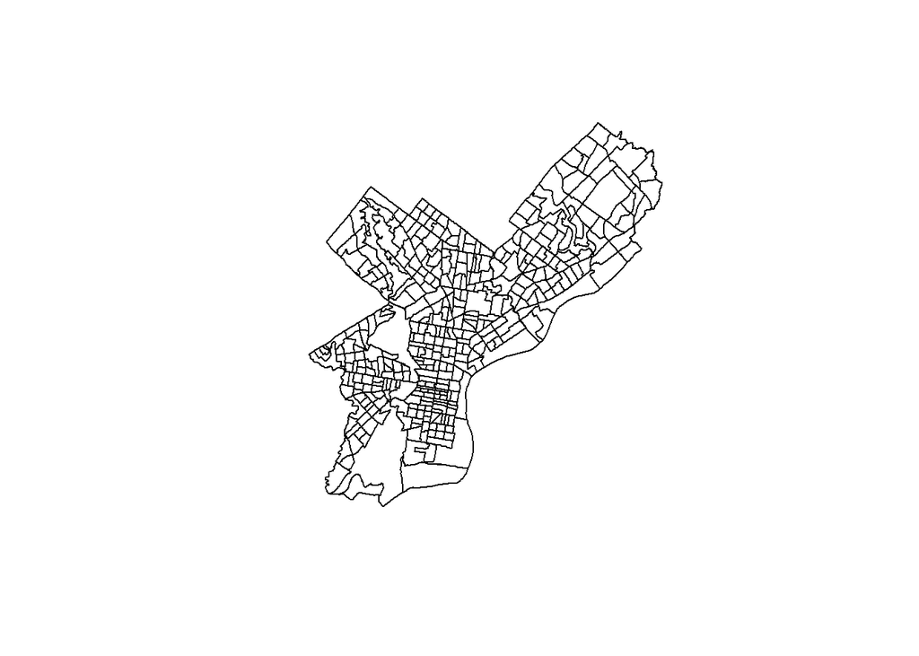

```r
# Plot the geometry of philly.tracts with the base plot function
plot(pt.geo)
```

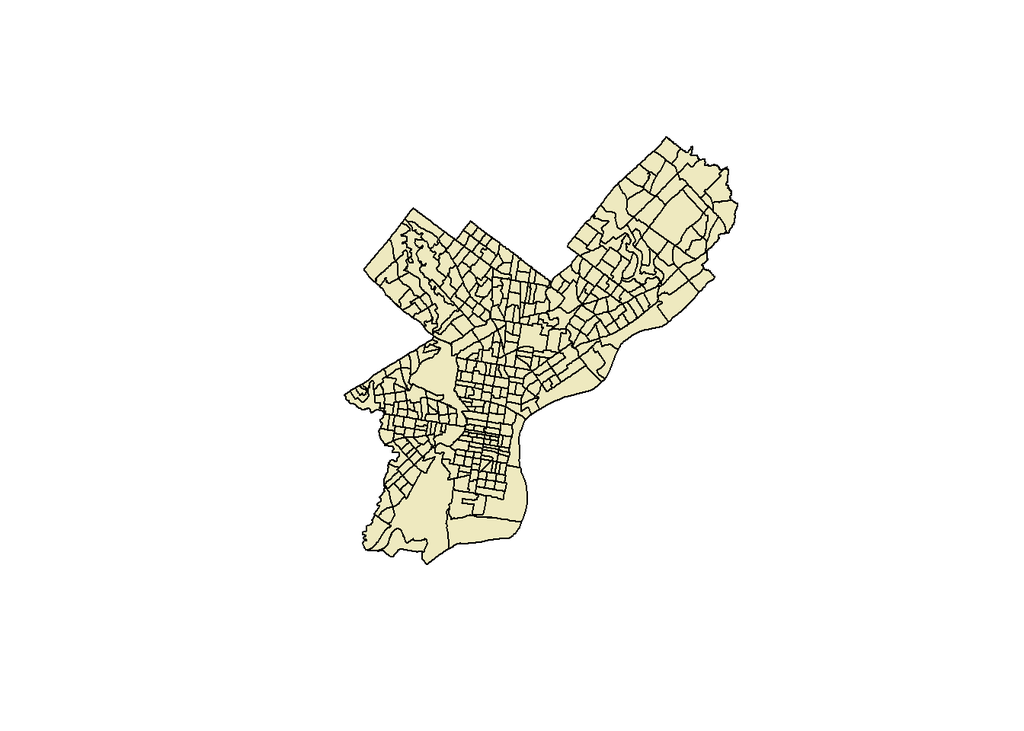

```r
# The base plot function has some aesthetic options we can use to tweak our plots
plot(pt.geo, col = "lemonchiffon2")
```

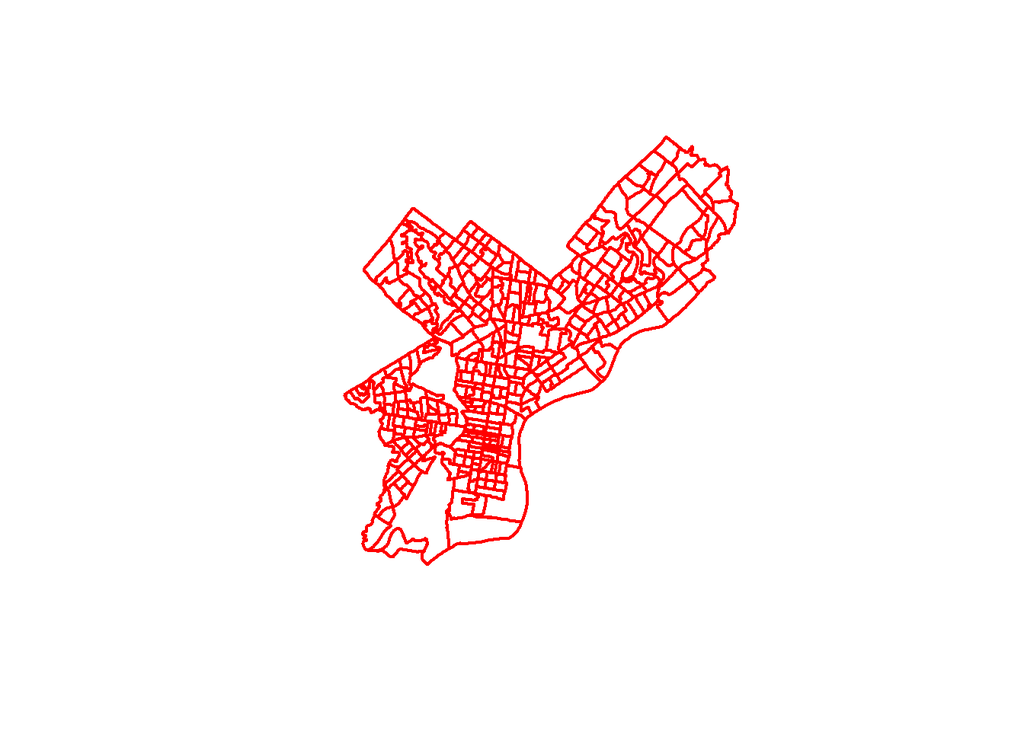

```r
plot(pt.geo, lwd = 2, border = "red")
```

```r
str(philly.tracts)
```

```
## Classes 'sf' and 'data.frame':   384 obs. of  15 variables:
##  $ OBJECTID  : int  1 2 3 4 5 6 7 8 9 10 ...
##  $ STATEFP10 : Factor w/ 1 level "42": 1 1 1 1 1 1 1 1 1 1 ...
##  $ COUNTYFP10: Factor w/ 1 level "101": 1 1 1 1 1 1 1 1 1 1 ...
##  $ TRACTCE10 : Factor w/ 384 levels "000100","000200",..: 95 96 97 134 135 136 137 138 139 140 ...
##  $ GEOID10   : Factor w/ 384 levels "42101000100",..: 95 96 97 134 135 136 137 138 139 140 ...
##  $ NAME10    : Factor w/ 384 levels "1","10.01","10.02",..: 369 370 371 43 44 46 47 48 49 50 ...
##  $ NAMELSAD10: Factor w/ 384 levels "Census Tract 1",..: 369 370 371 43 44 46 47 48 49 50 ...
##  $ MTFCC10   : Factor w/ 1 level "G5020": 1 1 1 1 1 1 1 1 1 1 ...
##  $ FUNCSTAT10: Factor w/ 1 level "S": 1 1 1 1 1 1 1 1 1 1 ...
##  $ ALAND10   : int  366717 319070 405273 341256 562934 439802 562132 789935 570015 609439 ...
##  $ AWATER10  : int  0 0 0 0 0 0 0 277434 282808 0 ...
##  $ INTPTLAT10: Factor w/ 384 levels "+39.8798897",..: 106 114 113 141 137 132 126 110 120 131 ...
##  $ INTPTLON10: Factor w/ 384 levels "-074.9667387",..: 350 362 370 257 234 208 168 129 113 135 ...
##  $ LOGRECNO  : Factor w/ 384 levels "10335","10336",..: 95 96 97 134 135 136 137 138 139 140 ...
##  $ geometry  :sfc_MULTIPOLYGON of length 384; first list element: List of 1
##   ..$ :List of 1
##   .. ..$ : num [1:36, 1:2] -75.2 -75.2 -75.2 -75.2 -75.2 ...
##   ..- attr(*, "class")= chr  "XY" "MULTIPOLYGON" "sfg"
##  - attr(*, "sf_column")= chr "geometry"
##  - attr(*, "agr")= Factor w/ 3 levels "constant","aggregate",..: NA NA NA NA NA NA NA NA NA NA ...
##   ..- attr(*, "names")= chr  "OBJECTID" "STATEFP10" "COUNTYFP10" "TRACTCE10" ...
```

```r
#join shapfile to ACS data
philly.tracts <- mutate(philly.tracts, GEOID = as.character(GEOID10))
class(acs.data)
```

```
## [1] "sf"         "data.frame"
```